# Week 3 Excersize Solutions

1. Let $X$ be a normal random variable with $\mu = 5$ and $\sigma = 10$. Find $P(X>10)$ and $P(-20 < X < 15)$.

First we can find the Z-score as follows $z = \frac{x - \mu}{\sigma} = \frac{10-5}{10} = 0.5$. This tells us that 10 is 0.5 standard deviations above the mean. Then we can look up this value on the [Z-table](http://www.z-table.com/). 0.6915 of the area under the standard normal distribution is to the left of 0.5. We want to know the area to the right of 0.5, which is 1 - 0.6915 = 0.3085.

```r
# P(X > 10)
1 - pnorm(10, mean = 5, sd = 10)
```

```
## [1] 0.3085375
```

```r
pnorm(15, 5, 10) - pnorm(-20, 5, 10)
```

```
## [1] 0.8351351
```

2. Suppose the mean height of students is $160$ $\text{cm}$, with a variance of $29$ $\text{cm}^2$ . What is the probability of a randomly selected student having a height of less than $155$ $\text{cm}$?

```r
(155-160)/sqrt(29)
```

```
## [1] -0.9284767
```

```r
pnorm(155, 160, sqrt(29))
```

```
## [1] 0.1765802
```

3. Suppose that a rare disease affects 1 in 1,000 (P = 0.001) people. Assuming that members of the population are affected independently, find the probability of k cases in a population of 100 000, for k = 0, 1 and 2. If you want, you can just write out the equation. This calculation can also be performed in R using the `dbinom()` function.

The equation for k = 0 is

$${1e5 \choose 0}0.001^0(1-0.001)^{1e5-0} = (1-0.001)^{1e5}$$

```r
dbinom(0:2, 100000, 0.001)
```

```
## [1] 3.538528e-44 3.542070e-42 1.772790e-40
```

4. What is the relationship between any normal distribution and the standard normal ($\mu = 0$, $\sigma^2 = 1$).

5. Dr. Wattie’s The Game:
   1. What is the probability that your professor loses his money on the first daily draw?
   2. Are the draws independent?

      No. The tickets are not replaced in the draw. So, each removed ticket changes the probability of selecting all remaining tickets.
   3. What is each player’s expected earnings?

This is determined by adding the expected earnings from winning to the expected earnings from losing. Each player as a 10/11 chance of losing, thus they have a 1/11 chance of winning. The expected earnings for a win is 1/11 * (25*11 - 25) = $22.73. The expected earnings for a loss is 10/11 * -25 = -22.73. So, each player is expected to end up with zero dollars. Of course, someone has to win, right?

4. Are they all fools?
5. Probably?
6. Skim the provided article by Kurdyak et al. (2015). Approximately, what is the probability that a person diagnosed with chronic psychotic disorder (using the algorithm explored in the paper) actually has the disease?

We can solve this by using Bayes’ Theorem. The prevalence of chronic psychotic disorder is between 0.5% and 1%. The recommended algorithm for diagnosing chronic psychotic disorder with administrative health data in Ontario has a sensitivity of 97.6% and a specificity of 58.7%.

$$P(D|T^+) = \frac{0.976*0.01}{0.976*0.01 + (1 - 0.587)*(1 - 0.01)}$$

$$= \frac{0.0098}{0.0098 + 0.4089} = 0.024.$$

## Computer Exercises

1. Imagine a cup containing two similar coins is shaken, then turned upside down on a table. What is the probability that both coins are heads? How did you determine this?
- Pitman (1993) provides the solution to this problem. I paraphrase it here:
- There are a number of ways of thinking about this. We could think of each coin as an independent toss where there are two possible outcomes: heads or tails. Thus, the chance that they are both heads is 1/2 because the sample space only contains two possibilities.
- If we count the number of heads on the coins, there is actually three possible outcomes in the sample space: 0, 1, or 2 heads. Assuming these are equally likely, we have a probability of 1/3 of getting 2 heads.
- If we think of the coins as being labeled in some way, then there are actually four possible outcomes `hh, ht, th, tt.` Thus, the probability of the coins showing two heads is 1/4.
- In formal probability theory, all of these solutions are correct. So, if you said any one of these, congratulations. Each is right insofar as we accept the assumptions that were made. However, only one set of assumptions holds in practice.
- The first solution is incorrect in that there is no remaining probability for the event that there is one tails and one heads. (.5 for heads, .5 for tails, and ? for one heads and one tails).
- The second and third solutions both seem plausible: does it really matter if you can distinguish between the coins? Well, the problem I’ve specified I’ve made a point to ensure that we cannot distinguish between them. So should the result be 1/3 chance of getting two heads?
- It turns out that in the long-run view of probability, the answer is 1/4 regardless of whether you can identify the individual coins. This is because physical objects, like coins, protons and electrons, behave statistically as though they can be distinguished.
- We can test this:

  ```r
  coin <- c(0,1)

  result <- sample(coin,
                   size = 10000,
                   prob = c(0.5,0.5),
                   replace = TRUE) +
            sample(coin,
                   size = 10000,
                   prob = c(0.5,0.5),
                   replace = TRUE)

  table(result)
  ```

  ```
  ## result
  ##    0    1    2
  ## 2405 5063 2532
  ```

3. Use the rnorm() function to draw 10, 100, 1,000 and 10,000 observations from a standard normal distribution. Take the mean of each draw and compare them to the population mean. What does this result tell you?

```r
set.seed(123)
mean(rnorm(10))
```

```
## [1] 0.07462564
```

```r
mean(rnorm(100))
```

```
## [1] 0.04335854
```

```r
mean(rnorm(1000))
```

```
## [1] 0.02024501
```

```r
mean(rnorm(10000))
```

```
## [1] -0.001858069
```

The law of large numbers kicks in with larger samples; the sample mean converges on the population parameter as the sample size increases.

4. Graph the distribution of each of the results in 3. What does this result tell you?

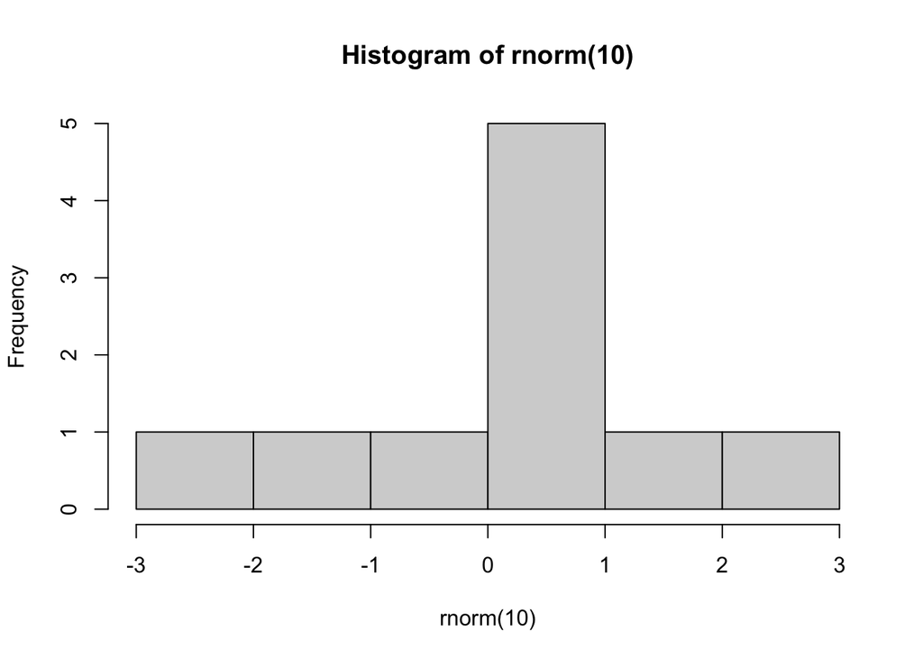

```r
set.seed(4444)
hist(rnorm(10))
```

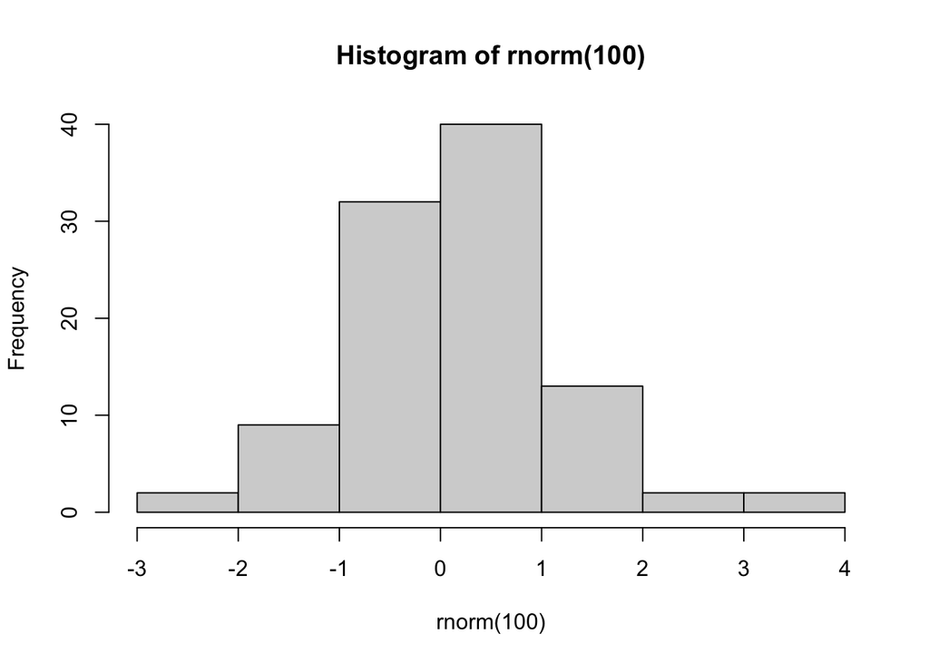

```r
hist(rnorm(100))
```

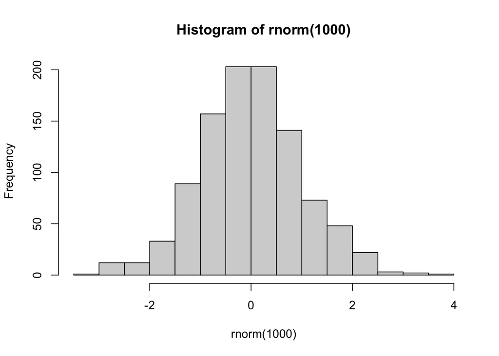

```r
hist(rnorm(1000))
```

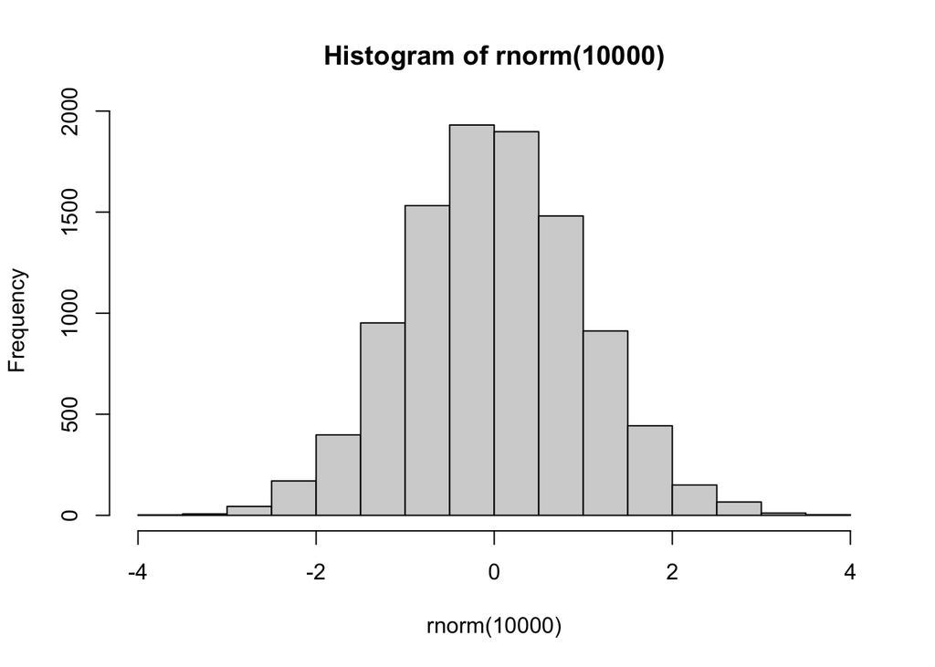

```r
hist(rnorm(10000))
```

The central limit theorem kicks in. The shape of the distribution (variance, skewness and kurtosis) converge on the population parameters as the sample size increases.